# Functionalizing Rasters from NEON

Cassondra Walker

June 21, 2016

# Objectives

1. Import a raster — A lidar canopy height model (lidar/Teak_lidarCHM.tif)
2. For the CHM, set values == 0 to NA (not trees)
3. Classify the raster according to some distribution – low medium and tall trees. This could be done using a histogram potentially or we could just decide that <2m is generally grasses / understory, <6m small trees,and the rest are tall trees. A function could import the desired thresholds. Visualize histogram/density and plot vertical cutoff lines.
4. Take the chm and create a hillshade (http://neon-workwithdata.github.io/neon-data-institute-2016/R/create-hillshade-R/)
5. PLOT - layer the classified raster on top of the hillshade, add a legend for each “class” - legends are super tricky to simplifying this process with a function would be good. see: http://neon-workwithdata.github.io/neon-data-institute-2016/R/classify-by-threshold-R/ for my take on forcing a legend outside of the plot area using par settings. You may have other better forms of magic to make this work well. :)
6. Export the plot figure to a pdf – publishable
7. Export the classified raster as a geotiff with NaFlagg = -9999 to an outputs folder.

## Load libraries

```r
library(raster)
library(rhdf5)
library(rgdal)
```

## Import a raster — A lidar canopy height model

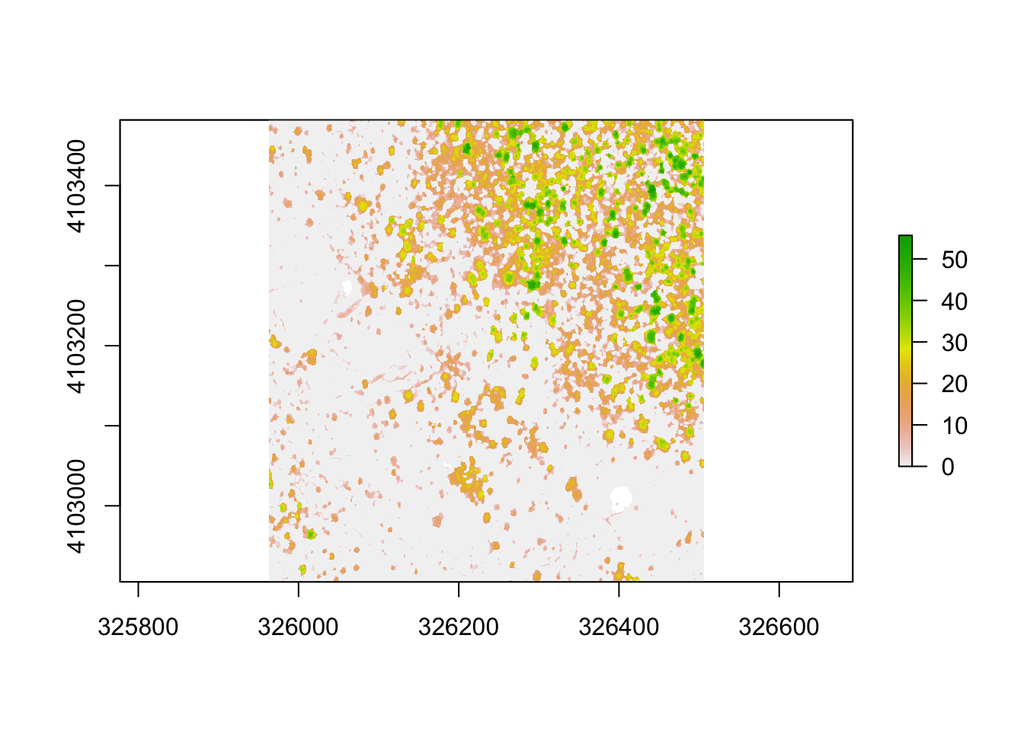

```r
canopy_hm <- raster("../NEONdata/D17-California/TEAK/2013/lidar/TEAK_lidarCHM.tif")

plot(canopy_hm)
```

## Get rid of zeros canopy height values

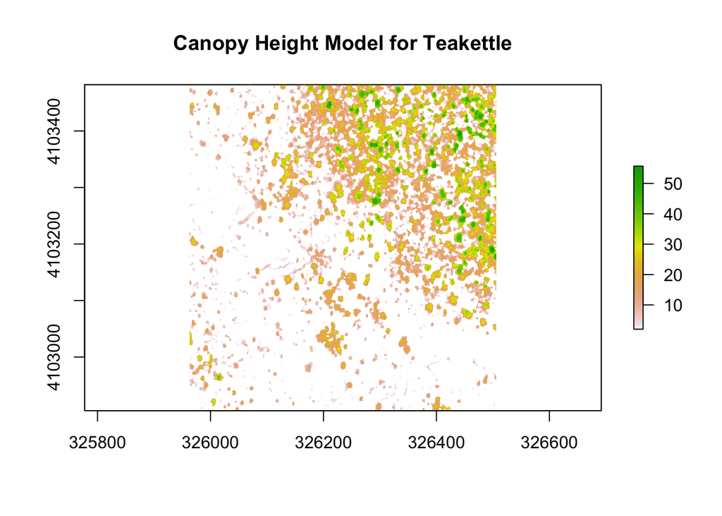

```r
canopy_hm[canopy_hm==0] <- NA

plot(canopy_hm,
     main = "Canopy Height Model for Teakettle")
```

## Define Classification Scheme

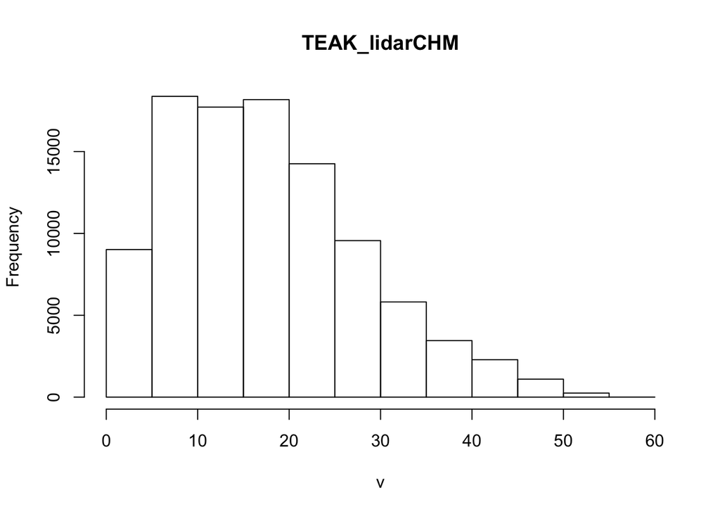

```r
# first check the distribution of tree height measurements to aid in choosing
#     height bins for classification

hist(canopy_hm)
```

```r
# Create matrix to define the height bins
# class 1 is low vegetation
# class 2 is medium vegetation
# class 3 is high vegetation

class.m <- c(0,3,1,
             1,6,2,
             5,60,3)

class.m
```

```
## [1]  0  3  1  1  6  2  5 60  3
```

```r
# change the class array into a matrix

class.matrix <- matrix(class.m,
                       ncol=3,
                       byrow=TRUE)

class.matrix
```

```
##      [,1] [,2] [,3]
## [1,]    0    3    1
## [2,]    1    6    2
## [3,]    5   60    3
```

## Classify raster using tree heights

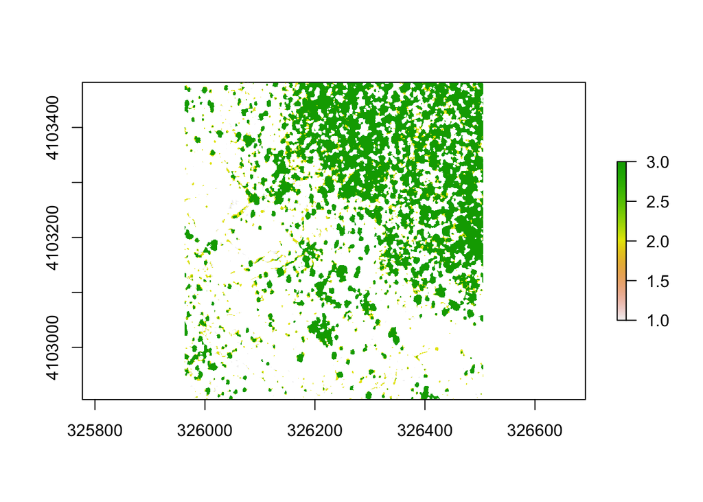

```r
# classify the raster using the scheme from previous code
chm.class <- reclassify(canopy_hm,
                        class.matrix)
plot(chm.class)
```

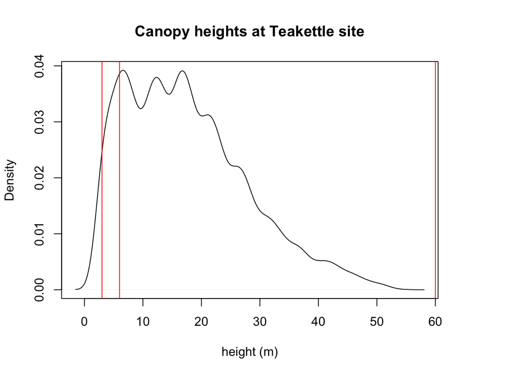

```r
density(canopy_hm,
        main = "Canopy heights at Teakettle site",
        xlab = "height (m)")

abline(v=class.matrix[,2], col="red")
```

```r
# Export PDF

pdf(file = "Teak_CHM_denisty_with_breaks.pdf",width=6,height=7)
```

## Clean up the figure

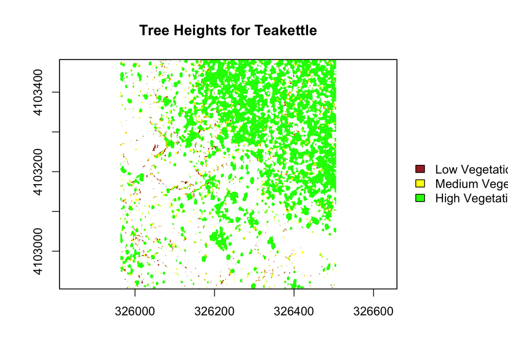

```r
# change margins of the plotting space
# xpd = FALSE means do not plot outside bounds
par(xpd = FALSE, mar=c(5.1, 4.1, 4.1, 4.5))

# plot reclassified raster with new margins and set up color scheme
plot(chm.class,
     col=c("brown","yellow","green"),
     main="Tree Heights for Teakettle",
     legend=F)

# allow legend to plot outside of bounds
par(xpd=TRUE)

leg.x <-par()$usr[2]+20
leg.y <- par()$usr[4] + 50 -(abs(par()$usr[3]-par()$usr[4])/2)

# create the legend
legend(leg.x, leg.y,  # set x,y legend location
       legend = c("Low Vegetation", "Medium Vegetation","High Vegetation"),
       fill = c("brown","yellow","green"),
       bty="n") # turn off border
```

# Export Geotiff

```r
writeRaster(chm.class,
            filename="../outputs/TEAK/Teak_Classified_CHM.tif",
            format="GTiff",
            options="COMPRESS=LZW",
            overwrite = TRUE,
            NAflag = -9999)
```